# Part I - Prosper Loan Data Analysis And Exploration

## Bivariate Exploration

> In this section, I will be investigating relationships between pairs of variables in the data. Some of the variables to be covered have been introduced in the univariate exploration section.

### Question 14

Does any of the features share a positive or negative relation with each other?

### Visualization

```python
# naming numerical variable for the # correlation plot
num_vars = ['BorrowerAPR', 'BorrowerRate','DebtToIncomeRatio',
            'StatedMonthlyIncome','LoanOriginalAmount','MonthlyLoanPayment',
            'LoanOriginationYear','Recommendations']
```

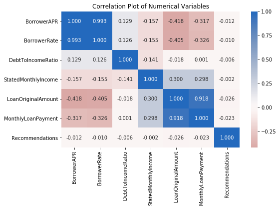

```python
# correlation plot
plt.figure(figsize = [8, 5])
sb.heatmap(loan_data[num_vars].corr(), annot = True, fmt = '.3f',
           cmap = 'vlag_r', center = 0)
plt.title('Correlation Plot of Numerical Variables')
plt.show()
```

### Observations

The heatmap shows that most of the variable share negative correlation. The features that share positive correlation include `(BorrowerRate, BorrowerAPR)` and `('LoanOriginalAmount, MonthlyLoanPayment)`

### Question 15

Examine the pairwise correlations present between features in the data

### Visualization

```
loan_data.shape= (77557, 23)
loan_samp.shape= (1000, 23)
```

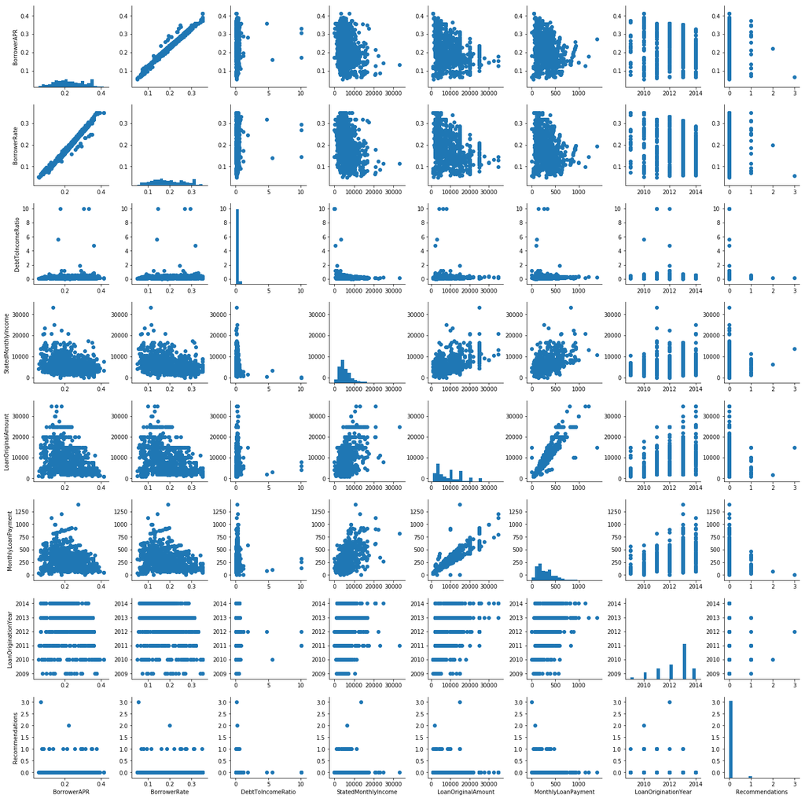

```python
# plot matrix: sample 500 diamonds so that plots are clearer and they render faster
print("loan_data.shape=",loan_data.shape)
loan_samp = loan_data.sample(n=1000, replace = False)
print("loan_samp.shape=",loan_samp.shape)

g = sb.PairGrid(data = loan_samp, vars = num_vars)
g = g.map_diag(plt.hist, bins = 20);
g.map_offdiag(plt.scatter);
```

### Question 16

Does BorrowerAPR share a positive relation with BorrowerRate?

### Visualization

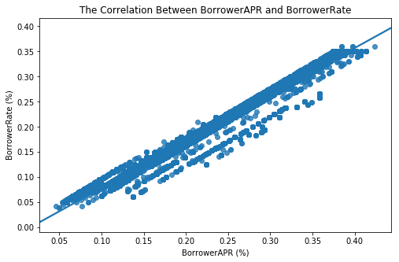

```python
# scatter plot with regression line
plt.figure(figsize=[8,5])
sb.regplot(data = loan_data, x = 'BorrowerAPR', y = 'BorrowerRate')
plt.xlabel('BorrowerAPR (%)')
plt.ylabel('BorrowerRate (%)')
plt.title('The Correlation Between BorrowerAPR and BorrowerRate');
```

### Observations

The fitted line further show the relationship between `BorrowerRate` and `BorrowerAPR`

### Question 17

Looking closely at the relationship between `MonthlyLoanPayment` and `LoanOriginalAmount`

### Visualization

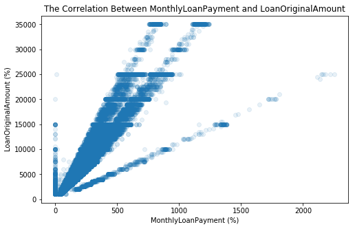

```python
plt.figure(figsize=[8,5])
# The scatter_kws helps specifying the opaqueness of the data points.
# The alpha take a value between [0-1], where 0 represents transparent, and 1 is opaque.
sb.regplot(data = loan_data, x = 'MonthlyLoanPayment', y = 'LoanOriginalAmount',
           fit_reg=False, x_jitter=0.3, scatter_kws=({'alpha':1/10}))
plt.xlabel('MonthlyLoanPayment (%)')
plt.ylabel('LoanOriginalAmount (%)')
plt.title('The Correlation Between MonthlyLoanPayment and LoanOriginalAmount');
```

### Question 18

What effect does the occupation of a borrower have on the loan amount they are granted?

### Visualization

```python
data = loan_data.sort_values('Occupation')
```

```
Text(0.5,1,' Average Loan Amount ($) by Occupation of Borrowers')
```

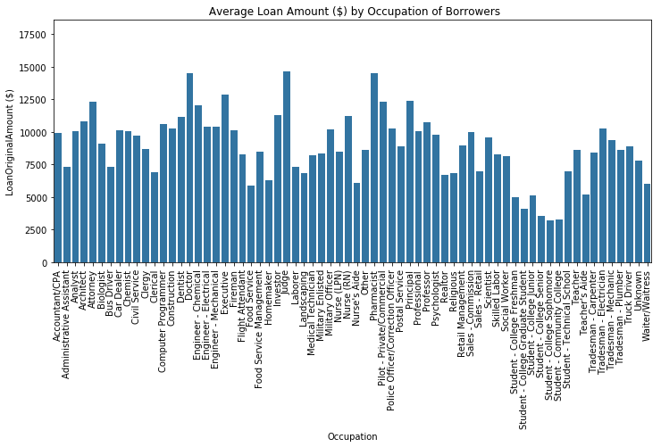

```python
plt.figure(figsize=[12,5])
sb.barplot(data=data, x='Occupation', y='LoanOriginalAmount', color=base_color, errwidth=0)
plt.xticks(rotation=90);
plt.ylabel('LoanOriginalAmount ($)')
plt.title(' Average Loan Amount ($) by Occupation of Borrowers')
```

### Observations

The professions that take out the highest amount of loan include **Pharmacy, Medicine(Doctor) and Jugde**. These professions do indeed hold a high prestige in the society. The average salary of anyone in any of the three professions is over ($)150,000

### Question 19

What effect does the beign an home owner have on the loan amount granted?

### Visualization

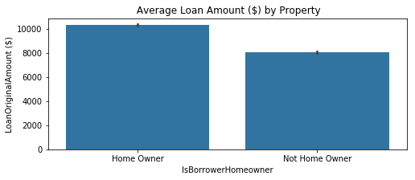

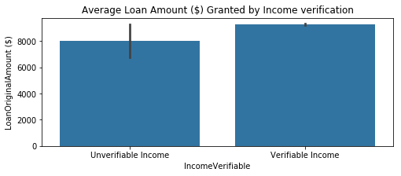

```python
plt.figure(figsize=[8,3])
sb.barplot(data=loan_data, x='IsBorrowerHomeowner', y='LoanOriginalAmount', color=base_color)
# plt.xticks(rotation=90);
plt.ylabel('LoanOriginalAmount ($)')
plt.title(' Average Loan Amount ($) by Property');

plt.figure(figsize=[8,3])
sb.barplot(data=loan_data, x='IncomeVerifiable', y='LoanOriginalAmount', color=base_color)
# plt.xticks(rotation=90);
plt.ylabel('LoanOriginalAmount ($)')
plt.title('Average Loan Amount ($) Granted by Income verification');
```

### Question 20

How does Prosper Rating affect BorroweAPR and viceversa

### Visualization

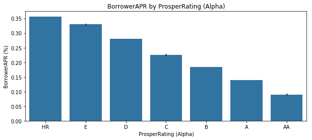

```python
plt.figure(figsize=[10,4])
base_color = sb.color_palette()[0]
sb.barplot(data=loan_data, x='ProsperRating (Alpha)', y='BorrowerAPR', color=base_color)
plt.ylabel('BorrowerAPR (%)');
plt.title('BorrowerAPR by ProsperRating (Alpha)');
```

### Observations

The lowest Prosper Rating - HR - is assigned to loans with the highest Borrower Annual Percentage Rate (APR), while the highest Prosper Rating - AA - is assigned to loans with the lowest Borrower Annual Percentage Rate (APR)

### Question 21

How `BorrowerRate` and `LoanOriginalAmount` correlate with the categorical variables.

### Visualization

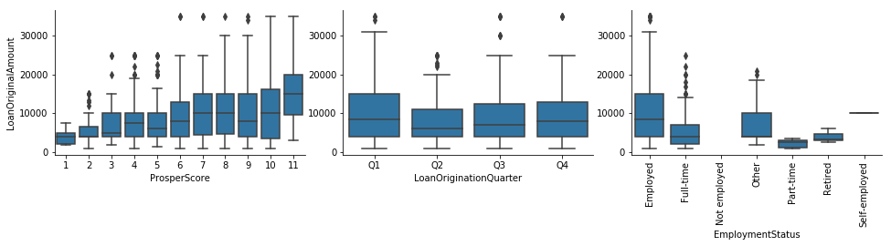

```python
loan_samp = loan_data.sample(n=2000, replace = False)
cat_vars = ['ProsperScore', 'LoanOriginationQuarter','EmploymentStatus']

def boxgrid(x, y, **kwargs):
    """ Quick hack for creating box plots with seaborn's PairGrid. """
    default_color = sb.color_palette()[0]
    sb.boxplot(x=x, y=y, color=default_color)

plt.figure(figsize = [10, 10])
g = sb.PairGrid(data = loan_samp, y_vars = ['LoanOriginalAmount'], x_vars = cat_vars,
                size = 3, aspect = 1.5)
g.map(boxgrid)
plt.xticks(rotation=90)
plt.show()
```

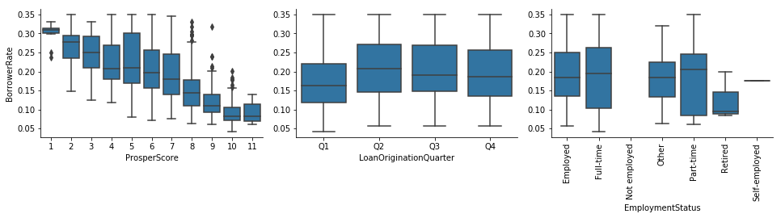

```python
plt.figure(figsize = [10, 10])
g = sb.PairGrid(data = loan_samp, y_vars = ['BorrowerRate'], x_vars = cat_vars,
                size = 3, aspect = 1.5)
g.map(boxgrid)
plt.xticks(rotation=90)
plt.show()
```

### Observations

Loan Original Amount shares a positive correlation with Prosper Score, but a negative correlation with Employment Status. The Loan Original Amount VS Loan Original Quarter shows that more loan is taken out in the first quarter (Q1) and the fourth quarter (Q2) while lesser loan is taken during the second quarter (Q2) and the third quarter (Q3). However Borrower Rate seems to be higher in Q2 and Q3 compared to Q1 and Q4.

### Question 22

What relationship is between the foloowing categorical variables? `ProsperRating (Alpha)`, `ProsperScore`, `EmploymentStatus`

### Visualization

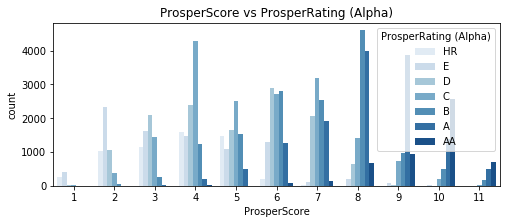

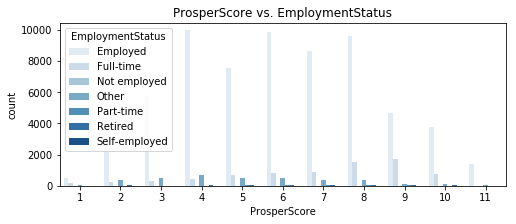

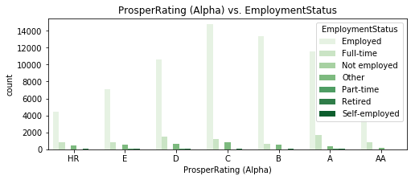

```python
# since there's only three subplots to create, using the full data should be fine.


# subplot 1: ProsperScore vs ProsperRating (Alpha)
plt.figure(figsize = [8, 3])
sb.countplot(data = loan_data, x = 'ProsperScore', hue = 'ProsperRating (Alpha)', palette = 'Blues')
plt.title('ProsperScore vs ProsperRating (Alpha)')
plt.show()

# subplot 2: ProsperScore vs. EmploymentStatus
plt.figure(figsize = [8, 3])
sb.countplot(data = loan_data, x = 'ProsperScore', hue = 'EmploymentStatus', palette = 'Blues')
plt.title('ProsperScore vs. EmploymentStatus')
plt.show()

# subplot 3: ProsperRating (Alpha) vs. EmploymentStatus
plt.figure(figsize = [8, 3])
sb.countplot(data = loan_data, x = 'ProsperRating (Alpha)', hue = 'EmploymentStatus', palette = 'Greens')
plt.title('ProsperRating (Alpha) vs. EmploymentStatus')
plt.show()
```

### Observations

There doesn't seem to be an interaction between prosper score and employment status as well as prosper rating and employment status, though proportionally it seems like there are more "Employed" borrowers who get prosper scores and prosper ratings than others. This is probably due to the fact that employed individual have better chances at securing loans than others. There are slightly larger interactions on the prosper score VS prosper rating, especially the mid levels of prosper scores ranging from 4 to 10

### Question 23

`ProsperScore` vs `IsBorrowerHomeowner`

### Visualization

```
Text(0.5,1,'ProsperScore vs IsBorrowerHomeowner')
```

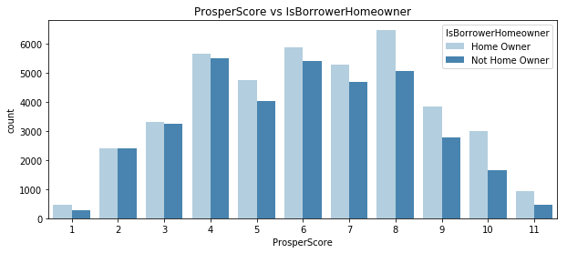

```python
plt.figure(figsize = [10, 4])
sb.countplot(data = loan_data, x = 'ProsperScore', hue = 'IsBorrowerHomeowner',palette = 'Blues')
plt.title('ProsperScore vs IsBorrowerHomeowner')
```

### Observations

The gaussian distribution suggests that is does not matter whether a borrower is an home owner or not. It does not affect the prosper score as employment status does. Owning a property does not guarantee securing a loan despite the fact that more home owners get the higher prosper scores, but the proportion is not too far behind. It would be a different story if 70% of people who do not own a home get only the lower prosper scores, and this is not the case.

### Talk about some of the relationships you observed in this part of the investigation. How did the feature(s) of interest vary with other features in the dataset?

> The loan original amount correlated beautifully with the monthly loan payment. Even though there are still are deaulted loans and loans that have missed their payment deadline, this does not affect the relationship. I did assume the relationship as the monthly loan payment will be calculated base on the term and loan amount, it was interesting to see. Also, just as much as employment status affects the loan amount, it affects the borrowerAPR just as much.

### Did you observe any interesting relationships between the other features (not the main feature(s) of interest)?

> I find it interesting that owning a property does not quarantee securing a loan or the amount which is granted. People who own homes and those who do not are granted loans regardless of how many properties they own. Apparently, what really matters is whether they are employed of not, do they a stable and secure income source?

## Multivariate Exploration

> In this section, I will be creating plots of three or more variables to investigate the data even further. The investigations are built on results from the previous Univariate Exploration and Bivariate Exploration sections.

### Question 24

`LoanOriginalAmount` by `BorrowerAPR` and `BorrowerRate`

### Visualization

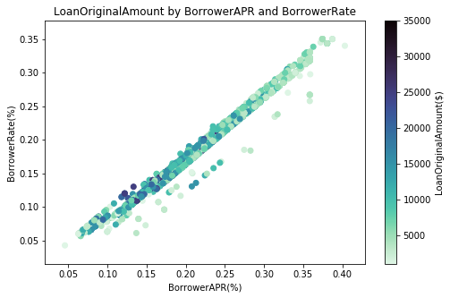

```python
plt.figure(figsize = [8,5])
plt.scatter(data = loan_samp, x = 'BorrowerAPR', y = 'BorrowerRate', c = 'LoanOriginalAmount',
            cmap = 'mako_r')
plt.colorbar(label='LoanOriginalAmount($)') #for 3rd variable
plt.xlabel('BorrowerAPR(%)')
plt.ylabel('BorrowerRate(%)')
plt.title('LoanOriginalAmount by BorrowerAPR and BorrowerRate');
```

### Observations

In the Bivariate section, I did investigate the relationship between BorrowerAPR and BorrowerRate as well as BorrowerAPR and LoanOriginalAmount separately, now I would like to examine the relationship between the three variable. Higher loan amounts seem to have lower BorrowerAPR nad BorrowerRate while the lower loan amounts have higher BorrowerAPR and BorrowerRate. There are also lower loan amounts that have low BorrowerAPR and BorrowerRate.

### Question 25

`MonthlyLoanPayment` by `DebtToIncomeRatio` and `StatedMonthlyIncome`

### Visualization

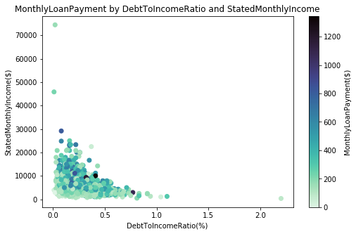

```python
plt.figure(figsize = [8,5])
plt.scatter(data = loan_samp, x = 'DebtToIncomeRatio', y = 'StatedMonthlyIncome', c = 'MonthlyLoanPayment',
            cmap = 'mako_r')
plt.colorbar(label='MonthlyLoanPayment($)') #for 3rd variable
plt.xlabel('DebtToIncomeRatio(%)')
plt.ylabel('StatedMonthlyIncome($)')
plt.title('MonthlyLoanPayment by DebtToIncomeRatio and StatedMonthlyIncome');
```

### Question 26

`LoanOriginalAmount` by `ProsperRating (Alpha)` and `IsBorrowerHomeowner`

### Visualization

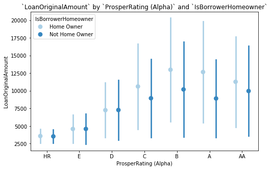

```python
plt.figure(figsize = [8,5])
plt.title('`LoanOriginalAmount` by `ProsperRating (Alpha)` and `IsBorrowerHomeowner`')
ax = sb.pointplot(data = loan_samp, x = 'ProsperRating (Alpha)', y = 'LoanOriginalAmount', hue = 'IsBorrowerHomeowner',
           palette = 'Blues', linestyles = "",dodge = 0.4, ci='sd')
```

### Question 27

`LoanOriginalAmount` by `ProsperScore` and `IncomeRange`

### Visualization

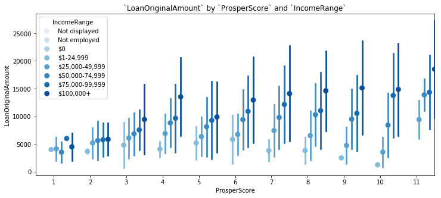

```python
plt.figure(figsize = [12,5])
plt.title('`LoanOriginalAmount` by `ProsperScore` and `IncomeRange`')
ax = sb.pointplot(data = loan_samp, x = 'ProsperScore', y = 'LoanOriginalAmount', hue = 'IncomeRange',
           palette = 'Blues', linestyles = "",dodge = 1, ci='sd')
```

### Visualization

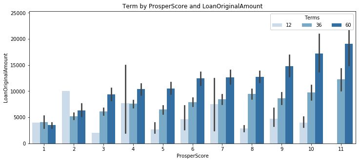

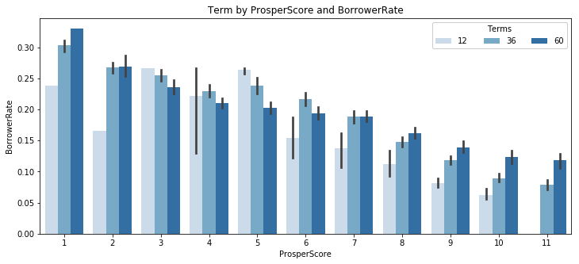

```python
# multivariate plot of Term by ProsperScore and LoanOriginalAmount
plt.figure(figsize = [12,5])
ax = sb.barplot(data = loan_samp, x = 'ProsperScore', y = 'LoanOriginalAmount', hue = 'Term', palette = 'Blues')
ax.legend(loc = 1, ncol = 3, framealpha = 1, title = 'Terms')
plt.title('Term by ProsperScore and LoanOriginalAmount')
plt.show()

# multivariate plot of Term by ProsperScore and BorrowerRate
plt.figure(figsize = [12,5])
ax = sb.barplot(data = loan_samp, x = 'ProsperScore', y = 'BorrowerRate', hue = 'Term', palette = 'Blues')
ax.legend(loc = 1, ncol = 3, framealpha = 1, title = 'Terms')
plt.title('Term by ProsperScore and BorrowerRate')
plt.show()
```

### Talk about some of the relationships you observed in this part of the investigation. Were there features that strengthened each other in terms of looking at your feature(s) of interest?

> Prosper score does not only increases or decreases by the loan amount but by the loan term as well. I did observe that high loan amounts can have low borrower rate and borrowerAPR.

## Conclusions

> More people took out laons in 2013 compared to other years, however, regardless of the year, people mostly take out loan in the first quarter (January-March) and fourth quarter (October-December)

> Owning a prperty or having a verifiable income does not guarantee securing a loan from Prosper. However, having a job helps in securing a loan, and also have a very high income betters the chances of securing a high loan

> To be a high income earner, pursuing a career as a judge, pharmacist or a doctor can put you in that income range with an income as high as 150000/yr

```python
data_copy.to_csv('loan_data.csv', index=False)
```